# Assignment 4

## Part 1: Getting to know ggplot

ggplot is a powerful and popular graphing toolbox for R. We’ll use it throughout the semester, and if you continue working with data in R, it will be an invaluable tool for you. ggplot’s syntax (the way it is typed) is strange at first, and there is definitely a learning curve. We’ll start with the basics. Because ggplot allows flexibility in how its commands are expressed, there are a variety of coding “styles”. If you are already comfortable with ggplot, you may write your code however you like. Take my suggestions in the assignment as one “style” that I find works for me.

We’ll work with a dataset containing arrest records in NYC. Download and extract the `arrests.csv` file from Courseworks. The dataset contains rows that are NYPD arrests from Jan 2020 through Jan 2021. Read the dataset into R using `read.csv()` (NOTE: Don’t use `readr` functions such as `read_csv()` for this, as some of the later steps may not make sense). Also, the beginning of a script is a good place to load libraries/packages you’ll use. If you don’t have `ggplot2` installed yet, do so by running `install.packages('ggplot2')`.

```r
library(ggplot2)
arrests = read.csv('arrests.csv')
```

The essential steps in designing a ggplot visualization are: (1) Initiating the plot with a call to `ggplot()` (2) Linking the data columns to a coordinate system (axes) with `aes()` (3) Displaying the data with a “geom” or shape, such as `geom_point()`

The choice of “geom” often requires the most thought, as certain geom’s only work for certain types of data. For example, a histogram, that shows a distribution of values of a continuous variable wouldn’t work a categorical variable, such as state or neighborhood.

Histograms are among the best tools to explore and summarize continuous data. Below, **use ggplot to make a histogram of precincts where arrests are made (`ARREST_PRECINCT`).** (yes, this isn’t really a continuous variable, but we can treat it as such here) First call ggplot(), passing in the `arrests` data frame as the only argument. Then, link the precinct variable to the x axis by giving `x = ARREST_PRECINCT` as the argument to `aes()`. Finally, add a histogram geom with `geom_histogram()` - it will work with no arguments, but have a look sometime at what arguments are available. Place each function call on its own code line, and include a `+` at the end of each line except the last one. If you end a line with `+` and hit enter/return, R will automatically indent the next line.

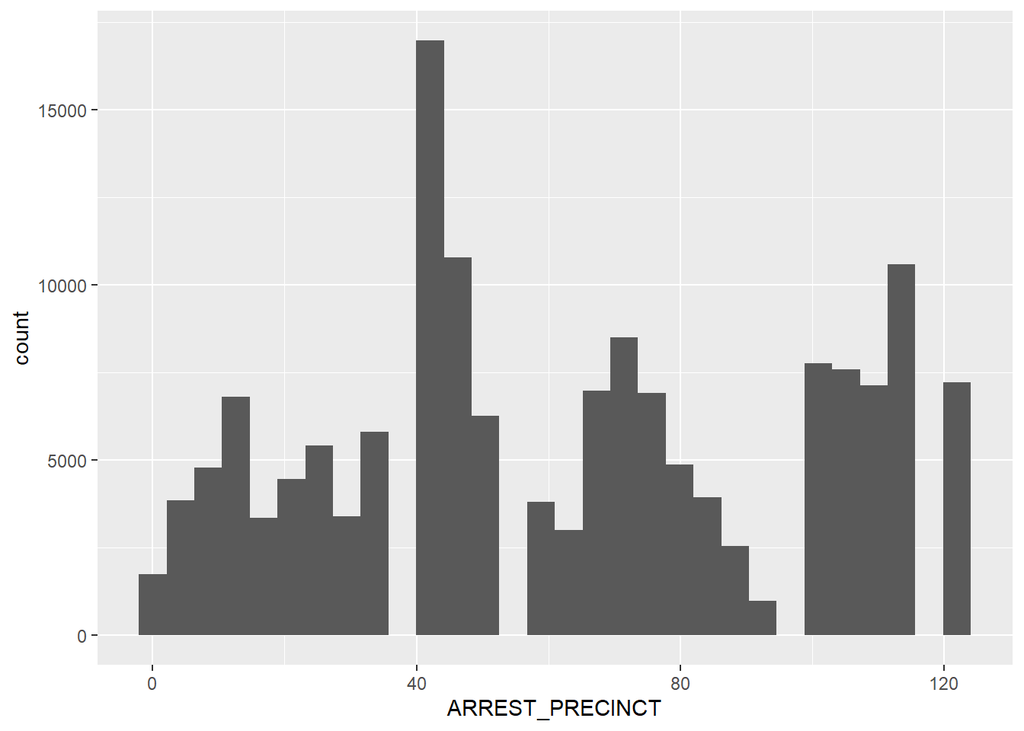

```r
ggplot(arrests) +
  aes(x = ARREST_PRECINCT) +
  geom_histogram()
```

From this plot, **does it appear that some precincts have higher arrest rates than others?**

In ggplot, aesthetics are the mapping of the data to the graph’s visual “canvas”. They link data columns to axes. This is separate from the geom’s that represent data points. Below, make a box plot showing arrest precincts by race by linking `PERP_RACE` to the x-axis and `ARREST_PRECINCT` to the y-axis in `aes()`. Use `geom_boxplot()` with no arguments to create the boxes.

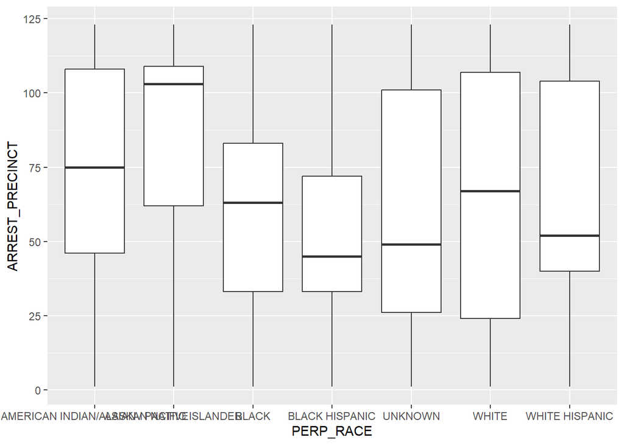

```r
ggplot(arrests) +
  aes(x = PERP_RACE, y = ARREST_PRECINCT) +
  geom_boxplot()
```

To illustrate the difference between aesthetics and geoms, **copy+paste your code above, but substitute `geom_boxplot()` with `geom_point()`.** You’ll see the axes have not changed, but instead of the data represented by boxes, there are now individual points for each observation. It’s very difficult to make sense of, because all the points are stacked on top of each other! **Copy+paste again, and substitute `geom_point()` with `geom_jitter()`.** The `jitter` geom modifies `geom_point()` by randomly shifting the points along one or both axes - this can be useful when data are densely packed. **One more time, copy+paste again and substitute `geom_jitter() for geom_violin()`.** A violin plot is a handy way to visualize distributions - the bubble is wide where data are concentrated, and narrow where data are sparse. (Note that RStudio will print one figure per code chunk. You can navigate multiple figures by clicking the thumbnails below the chunk)

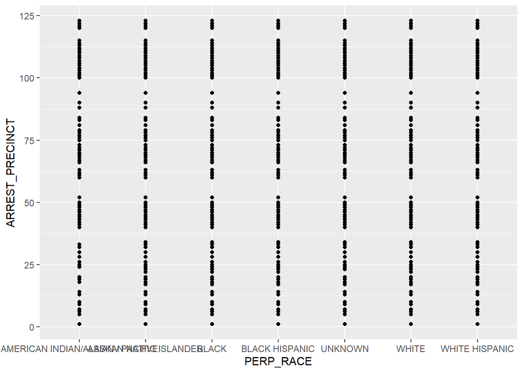

```r
# Use geom_point() here
ggplot(arrests) +
  aes(x = PERP_RACE, y = ARREST_PRECINCT) +
  geom_point()
```

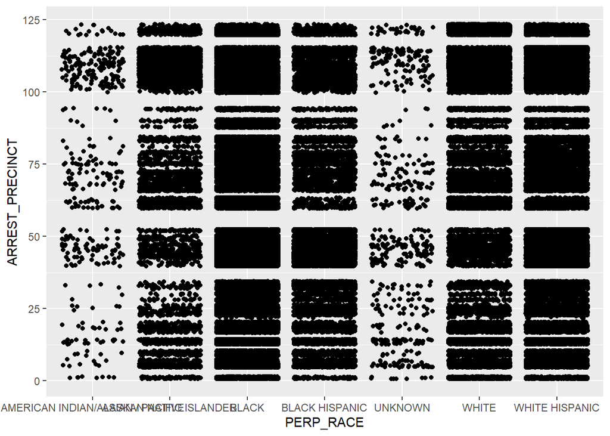

```r
# Use geom_jitter() here
ggplot(arrests) +
  aes(x = PERP_RACE, y = ARREST_PRECINCT) +
  geom_jitter()
```

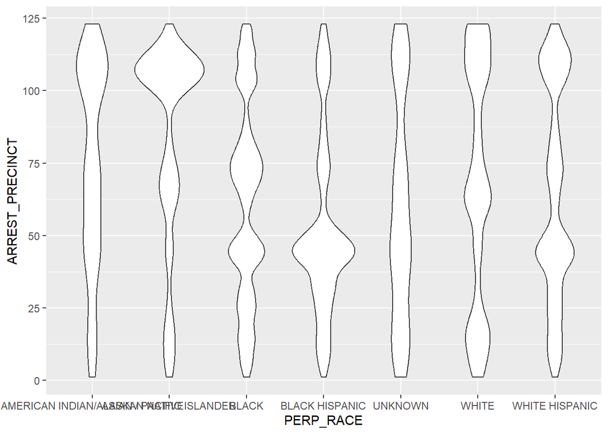

```r
# Use geom_violin() here
ggplot(arrests) +
  aes(x = PERP_RACE, y = ARREST_PRECINCT) +
  geom_violin()
```

Notice that you didn’t change the aesthetic `aes()` mapping here - only the shapes, `geom`, used to represent the data. The choice of the best representation often comes down to the `geom`.

You can map data to aesthetics (axes) other than just x- and y-axes. Often we’ll use color to distinguish groups or represent data values. **Below, copy+paste the boxplot you made above, but link the `PERP_SEX` variable to an additional aesthetic.** Try it with both `color = PERP_SEX` and `fill = PERP_SEX` (do only one or the other, then see what happens if you have `PERP_SEX` linked to both `color` and `fill`)

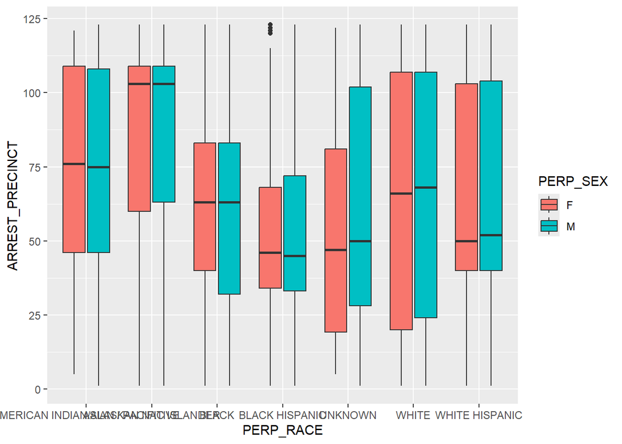

```r
ggplot(arrests) +
  aes(x = PERP_RACE, y = ARREST_PRECINCT, fill = PERP_SEX) +
  geom_boxplot()
```

**How are `color` and `fill` different?**

## Part 2: Making the visualization look good

So far we’ve covered how to represent data using aesthetics and geoms. But a crucial aspect of visualizations is that they must be legible and clear to anyone who will view them. Remember, the main point of producing a visualization is to communicate a result to other people! Importantly, a clean and clear graph buys you credibility, making it more likely others will take your work seriously, and hopefully learn something new.

There’s a lot we can do to clean these plots up. Copy+paste one of the plot codes you made above into the chunk below (any one you like except the histogram). **Assign the plot to an object called `plt` or `p` or some short name.** When you do this, RStudio won’t display the plot - instead you’ll see the plot object in your environment. You can now continue modifying that plot with `p + your_functions()`. You can see the plot anytime by typing the object’s name, `p`, and executing.

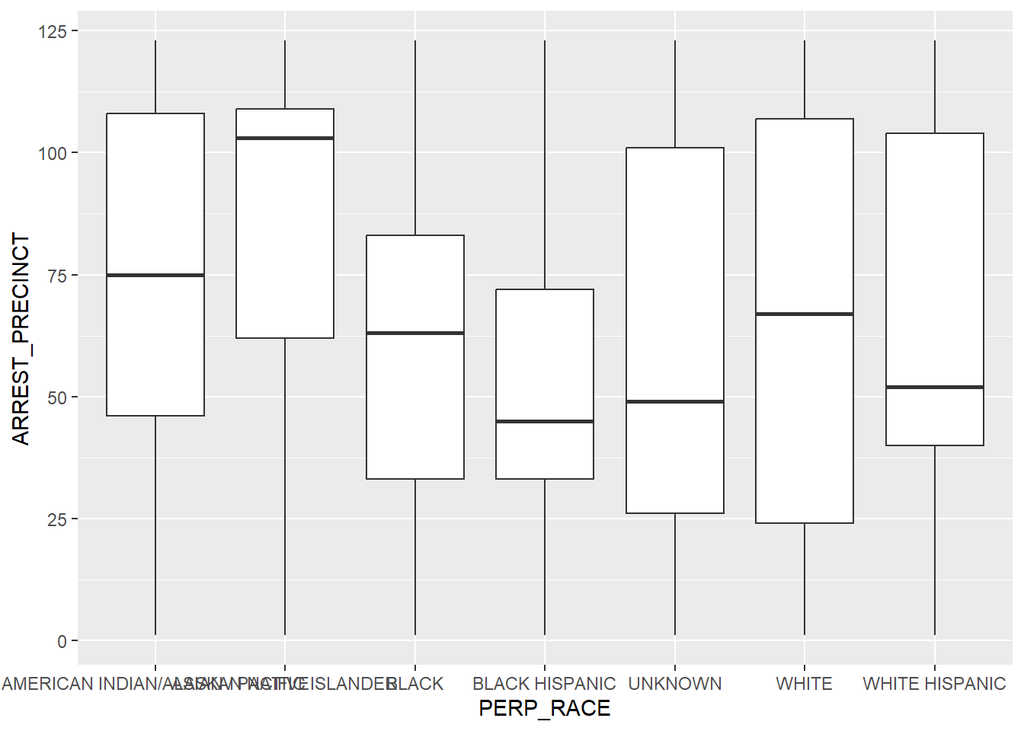

```r
# p = ggplot() # your plotting code here

p = ggplot(arrests) +
  aes(x = PERP_RACE, y = ARREST_PRECINCT) +
  geom_boxplot()

p     # View the plot
```

First off - on my computer, I can’t read the axis labels because they’re too long and they overlap. We can get full control over axis styling using `theme`s. `Theme`s control the visual appearance of the plot that is not data (which is controlled by aesthetics). By accessing `theme` elements, we can adjust tick marks, tick spacing, tick labels, background colors, gridlines, axis lines, and so on. Each `theme` property has an `element` associated with it, such as `element_line()` for line objects like tick marks, or `element_text()` for text objects like tick labels. These can be a bit tricky to understand at first, so **run the code chunk below, and study the structure of the `theme()` line for a moment.**

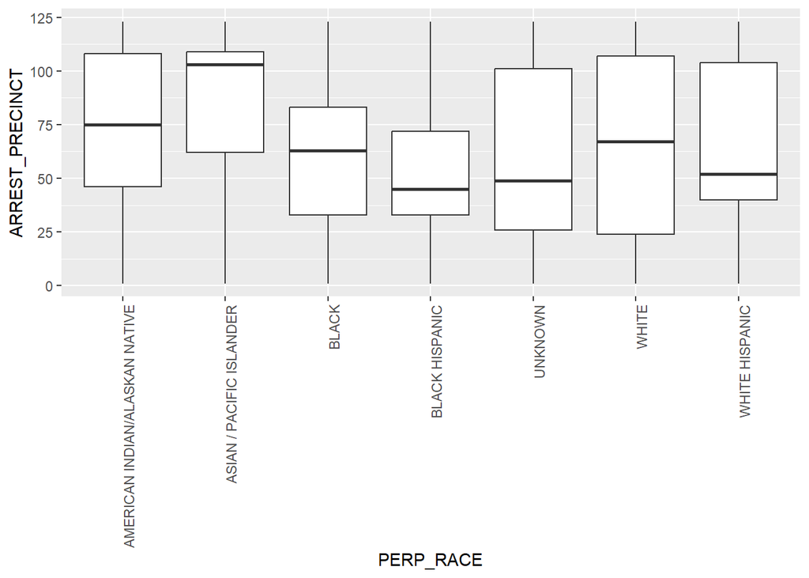

```r
# Reassign the plot to itself, to store the changes we're about to make
p = p +
  theme(axis.text.x = element_text(angle = 90, hjust = 1))

# Now view the plot again
p
```

**What changed in the plot?** Play around with the arguments to `element_text()` to get a feel for what they do. (try setting angle to 45 or 180, and hjust to 0.5 or 0)

While we’re on `theme`s, let’s fix up a few more things. Often, you’ll change many thematic/styling elements at once, so it can be useful to group them (that’s my opinion!). Rather than call `theme()` many times, we can set all our `theme` changes in one `theme()` call. Run the code below to see the changes I’ve started. **Complete the `theme()` call by giving an `element_line()` to both `axis.line.x` and `axis.line.y`.** You can run `?theme` in the console to see the theme properties you have control over, and, for example `?element_line` to see what element properties you can customize. The possibilities are endless!

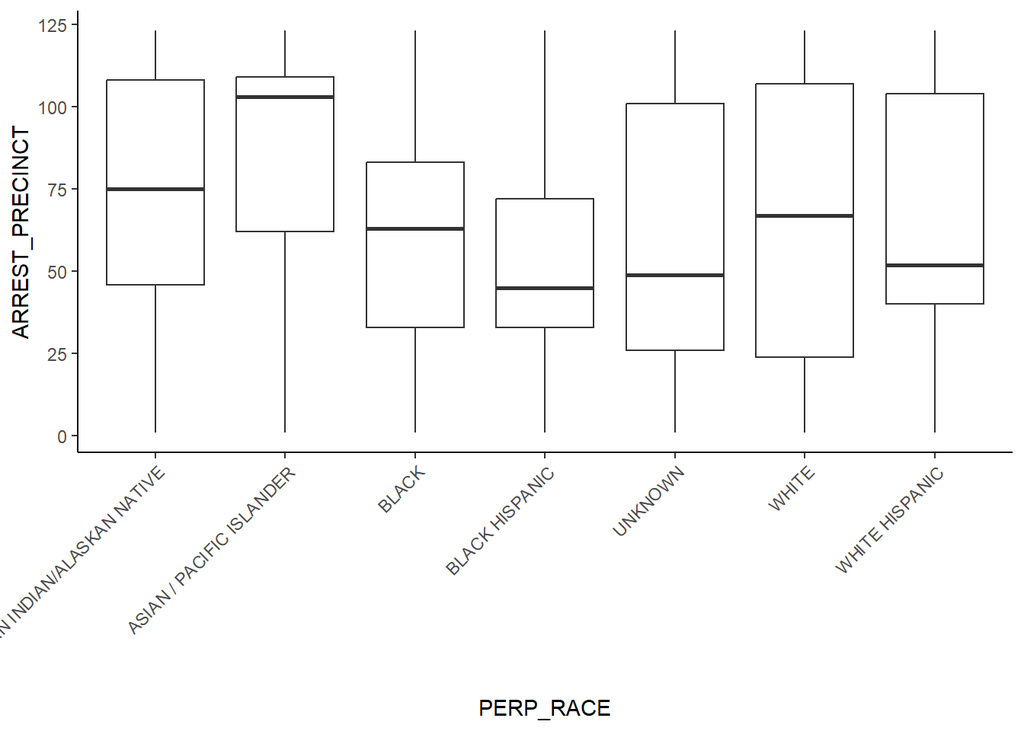

```r
p = p +
  theme(axis.text.x = element_text(angle = 45, hjust = 1, vjust = 1),
        panel.background = element_blank(),
        axis.line.x = element_line(),
        axis.line.y = element_line())
p
```

ggplot has many pre-built custom themes as well, which you can quickly add with, for example, `theme_bw()`, or `theme_classic()`. Look online for a full list. But if you learn how to work with `theme` properties, you will have complete control of how your plot looks! Trust me, it’s worth the investment.